[figure not shown]

Tutorial for ArcGIS Pro 3.4  
R-ArcGIS Scripting

# Tutorial Overview

R is an open-source statistical computing language that offers a large suite of data analysis and statistical tools, and is currently the de facto standard for statistical data analysis and visualization for academics and other communities. While its various third-party packages introduce a variety of advanced spatial statistical capabilities, it can be a challenge to access many spatial datasets. The **R-ArcGIS** bridge solves this challenge by providing an `arcgisbinding` package that allows ArcGIS datasets to be read and written easily from the R programming language. This tutorial will introduce you to the use of the R-ArcGIS Bridge in R scripts, and enable you to integrate ArcGIS datasets into your R statistical processes. It will also give you the pre-requisite knowledge to create script tools in ArcGIS that execute R functions, which will be covered in the following tutorial in this series.

### Skills

By completing this tutorial, you will become comfortable with the following skills:

- Reading/writing ArcGIS datasets using the `arcgisbinding` package.
- Working with ArcGIS datasets in R
- Manipulating and analyzing spatial data in R

### Time required

The following classroom time is required to complete this tutorial:

- 45 - 60 minutes

### Materials Required

- *Technology*:
  - ArcGIS Pro 3.4
  - Internet browser (e.g., Mozilla Firefox, Google Chrome, Safari)
  - R Statistical Computing Language – version 4.3.3
  - R-ArcGIS Bindings – version 1.0.1.311
  - RStudio Desktop – version 2024.09.0+375
- *Data*:
  - Data for this tutorial are included as part of the download in the packaged `data` folder.

### Data Sources

- City of Toronto:  
  https://www1.toronto.ca/wps/portal/contentonly?vgnextoid=1a66e03bb8d1e310VgnVCM10000071d60f89RCRD
- Statistics Canada:  
  http://www12.statcan.gc.ca/census-recensement/2016/dp-pd/index-eng.cfm

### Production Date

The Education and Research Group at Esri Canada makes every effort to present accurate and reliable information. The Web sites and URLs used in this tutorial are from sources that were current at the time of production, but are subject to change without notice to Esri Canada.

- Production Date: October 2018
- Updated: December 2024

## Background Information

The R user community has seen substantial growth in recent years, and is expected to continue growing due to the increasing popularity of statistical data analysis. You can use R in conjunction with ArcGIS to develop tools that can broaden the functionality of ArcGIS. Before you can create these tools, you need to develop an understanding of how to work with the `arcgisbinding` package that is installed by the **R-ArcGIS** bridge. Learning how to incorporate ArcGIS datasets into your R scripts to perform data analysis will greatly extend the possibilities that exist for analyzing both spatial and non-spatial data.

R is different from many other programming languages, in that it was developed primarily for data analysis and computational statistics. While the language and environment have evolved over the past two decades to incorporate many other capabilities, this initial focus provides R with almost every statistical model and data manipulation technique that you would need for modern data analysis. However, it can be a challenge to integrate with other data types or software environments.

The `arcgisbinding` package resolves the challenge of working with ArcGIS datasets by introducing to R a set of functions and classes that facilitate reading, writing, and manipulating ArcGIS datasets in the R programming language. It further enables integration of R with ArcGIS software through the ability to create script tools in ArcGIS toolboxes that execute R code.

By completing this tutorial, you will become familiar with the use of the `arcgisbinding` and the capabilities it introduces to the R environment. You will learn how to read and write data from ArcGIS datasets, and manipulate and analyze spatial data in the R programming language.

### References and Reading

- R-ArcGIS Bridge: full documenation for the `arcgisbinding` package  
  https://r-arcgis.github.io/assets/arcgisbinding.pdf
- R-ArcGIS Bridge: vignette for the `arcgisbinding` package  
  https://r-arcgis.github.io/assets/arcgisbinding-vignette.html
- R-Stats group on GeoNet  
  https://geonet.esri.com/groups/rstats
- R Statistical Computing Language  
  http://www.r-project.org/
- Spatial ‘view’ of packages in the Comprehensive R Archive Network  
  https://cran.r-project.org/web/views/Spatial.html

# Part A: Getting Started

To prepare for this workshop, you should have successfully completed the *Getting Started* and *R Scripting Basics* tutorials, which will ensure that you the required software installed and configured, as well as the basic R scripting skills necessary to complete this tutorial. From the *R Scripting Basics* tutorial, should be familiar with the **R** and **RStudio** software, and be able to work with the R Markdown format within the **RStudio** IDE. In this tutorial, everything discussed can be completed using the default **RGui** installed with **R**. However, this document is available as an R-Markdown file that you can open and use interactively in **RStudio**. If you choose instead to use **RGui** or another IDE, you can copy/paste code snippets into any R console or R script, or otherwise or adapt the code in another IDE environment.

## Setup

To work with the R Markdown source for this document:

1. Open the *`r-arcgis-rstudio.Rproj`* file in **RStudio**
2. Open the *File* tab in the top-right panel (based on the layout options recommended in the *R Scripting Basics* tutorial), and click on the file named *`3-R-ArcGIS-Scripting.Rmd`*. The R-Markdown source code for this document will open in the *Source* editor window in the top-left.
3. In the top-right corner of the source editor, you may click the maximize icon to toggle the maximized state of the panel, and use as much screen space as possible to display the document’s source code.

*Note:* The remainder of this document is written with the expectation that you are working with the R Markdown file in **RStudio**. If not, you may manually copy R commands enclosed in the ```{r} code blocks into any R console, provided that your current working directory (reported by `getwd()`) corresponds with the location where the tutorial files are located.

Before proceeding to interactively run code in the rest of the R Markdown document, select *Restart R and Clear Output* from the menu, and then run the following block to configure the R environment to help with the display of outputs in the resulting R Notebook, and to prepare a `example.gdb` file geodatabase from an empty template in the `data/` folder:

```r
# Run this line to disable magic quotes in output...
options(useFancyQuotes = FALSE)

# If a copy of example.gdb exists, delete it...
if (file.exists('data/example.gdb')) {
  unlink('data/example.gdb', recursive = TRUE)
}

# Create a new folder named 'example.gdb' and copy the contents of 'empty.gdb' into it:
if (!file.exists('data/example.gdb')) {
  dir.create('data/example.gdb')
  invisible(file.copy(paste0('data/empty.gdb/',list.files('data/empty.gdb')), 'data/example.gdb', overwrite = TRUE, recursive = FALSE, copy.mode = TRUE))
}
```

## Load the R-ArcGIS `arcgisbinding` package

In any stand-alone R script, you must load the `arcgisbinding` package in the current R session, and then call `arc.check_product()` before you can use any of the functionality provided by the `arcgisbinding` package. In the next tutorial, you will learn that this is not required when using an R script configured as a script tool in an ArcGIS Toolbox. However, it is a step that must always be performed to use `arcgisbinding` methods from an R console or in an R IDE such as **RStudio**.

To get started using the `arcgisbinding` package in this tutorial, run the block of code below to load the package and bind to your **ArcGIS Pro** or **ArcGIS Desktop** (ArcMap) software in your current R session:

```r
library(arcgisbinding)
arc.check_product()
```

```
product: ArcGIS Pro (13.4.0.55405)
license: Advanced
version: 1.0.1.311
```

*Hint: Remember from the* R Scripting Basics* tutorial that the `helper-functions.R` script included in the tutorial files provides methods that do this for you. You can try replacing the lines above with the R command to `source()` the helper script, and then use the `load_pkgs()` function. You could also replace any `library()` statements in the remainder of this document with `load_pkgs()`, which would ensure any missing CRAN packages are be installed automatically from the Internet.*

# Part B: Reading data from ArcGIS Datasets

The `arcgisbinding` package provides two methods that enable you to easily read data directly from ArcGIS datasets. For reading data, you will use `arc.open()` to create dataset objects that essentially serve as a connection to an existing ArcGIS dataset. With a dataset object, you may then use `arc.select()` to connect to existing datasets and read features/tables into data frames in the R workspace, or `arc.raster()` to load raster datasets.

## Connecting to an ArcGIS dataset

To use the `arc.open()` method to connect to an existing ArcGIS dataset, you must provide it with a single argument that specifies a path. The path must point to a standard feature class, feature layer, table, or raster dataset in a format supported by ArcGIS Pro or ArcGIS Desktop. These include simple files (e.g., shapefiles, csv, dBASE), geodatabases (file/enterprise), feature dataset components, GeoTiff images, etc. In 64-bit/Pro, feature service URLs will also work.

The returned result from the `arc.open()` method is a dataset object, which contains details about the spatial characteristics and attributes contained within the dataset.

**Note:** When specifying paths, be sure to escape backslashes (using double-backslashes), or use forward slashes. Paths may be absolute paths (starting with a drive letter (e.g., `C:/`), or a network share (`//hostname/share/`)), or they can be relative to the current working directory (that you can get or set the with `getwd()` and `setwd()` commands)

Start by opening the polygon boundaries for census subdivisions from Statistics Canada for the 2016 Census:

```r
?arc.open
csd <- arc.open("data/census/census2016.gdb/CensusSubdivisions")
```

You can report a summary of the dataset, or inspect several attributes as object properties (path, dataset_type, extent, fields, and spatialinfo) using the `@` operator:

```r
csd
```

```
dataset_type    : FeatureClass
path            : data/census/census2016.gdb/CensusSubdivisions
fields          : OBJECTID, Shape, CSDUID, CSDNAME, CSDTYPE, PRUID, PRNAME, CDUID, CDNAME, CDTYPE, CCSUID, CCSNAME, ERUID, ERNAME,
fields          : SACCODE, SACTYPE, CMAUID, CMAPUID, CMANAME, CMATYPE, Shape_Length, Shape_Area
extent          : xmin=3689439, ymin=659338.9, xmax=9015737, ymax=5242179
geometry type   : Polygon
WKT             : PROJCS["PCS_Lambert_Conformal_Conic",GEOGCS["GCS_North_Ameri...
```

```r
csd@shapeinfo
```

```
geometry type   : Polygon
WKT             : PROJCS["PCS_Lambert_Conformal_Conic",GEOGCS["GCS_North_Ameri...
```

```r
csd@extent
```

```
     xmin      ymin      xmax      ymax
3689439.0  659338.9 9015736.6 5242179.2
```

## Reading an ArcGIS dataset into a data frame

To load data from the connection into a data frame in the current R session, use the `arc.select()` method. This method requires a dataset object created by the `arc.open()` as its first argument. You may also optionally supply any of the four following as positional or named arguments:

- `fields` - A character vector of one or more fieldnames to select. Defaults to `'*'` (i.e., to select all fields)
- `where_clause` - An optional string representing an SQL query to filter features read from the dataset. Defaults to an empty string (i.e., to select all records)
- `selected` - In the context of a script tool, if records are selected in the layer or table from the corresponding ArcGIS Pro or ArcGIS Desktop session, then only those records will be read into the R session. Defaults to `TRUE`.
- `sr` - If set to a well-known ID, well-known text, or Proj.4 text representation of a spatial reference, features will be automatically reprojected as they are read into the R session. Defaults to NULL (i.e., features will be read in their original spatial reference)

Load the CSD boundaries for Canada, and keep only the province name, CSD name, and CSD Identifier attributes:

```r
?arc.select
csd_df <- arc.select(csd, c("PRNAME", "CSDNAME", "CSDUID"))
```

The same data could be read with by providing the desired fieldnames as a named argument to the `arc.select()`:

```r
csd_df <- arc.select(csd, fields = c("PRNAME", "CSDNAME", "CSDUID"))
class(csd_df)
```

```
[1] "arc.data"   "data.frame"
```

**Tip:** using named arguments allows you to execute the function without memorizing the positional order of optional arguments, and/or omit optional that you do not want to define. Also note the use of the `=` operator for named arguments, versus the `<-` assignment operator.

# Part C: Working with ArcGIS datasets in R

Once you have loaded data from an ArcGIS dataset into an R session, you can work with it like any regular data frame. For example, you may want to load join some additional tabular data and join it to boundaries to enable you to perform spatial analyses using a variety of spatial statistical packages in R. Do do this, you could load a feature layer that already has data joined to it from an ArcGIS Pro or ArcGIS Desktop session, or by reading data from feature layer that has a pre-defined join in it.

## Manipulating ArcGIS spatial data frames

It is also possible to join two datasets easily within the R language using functionality provided by the `dplyr` package. In the code block below, income data from the 2016 census aggregated at the census subdivision level are loaded from an ArcGIS file geodatabase table. An SQL clause is applied to limit features to those with valid global non-response rates below 25%, and the results are joined to the `csd_df` data frame containing the census subdivision boundaries. The forward-pipe operator `%>%` is used to chain the `arc.open()`, `arc.select()` and `right_join()` methods in a single command, with the result assigned to the `csd_income` variable:

```r
library(dplyr)
# Load income data for dissemination areas, and join by the csd geo_code the boundary data frame:
csd_income <- arc.open('data/census/census2016.gdb/income2016csd') %>%
  arc.select(c("geo_code", "gnr", "pop2016_t", "popdens_t", "income_median_t"), where_clause = "gnr is not null and gnr < 25") %>%
  right_join(csd_df, by = c("geo_code" = "CSDUID"))
class(csd_income)
```

```
[1] "arc.data"   "data.frame"
```

This join operation produces a new data frame that does not include the spatial information from the original `csd_df` data frame. To attach the joined attributes back to the `csd_df` data frame, we can assign columns directly. This can be done because the `csd_df` data frame was provided as the ‘right’ data frame in the `right_join()` method above, so the resulting `csd_income` data frame has the same number and order of rows:

```r
# Add columns back to the boundaries data frame:
csd_df$income_median_t <- csd_income$income_median_t
csd_df$pop2016_t <- csd_income$pop2016_t
csd_df$popdens_t <- csd_income$popdens_t
csd_df$gnr <- csd_income$gnr
```

It can be useful to rank or categorize data. For example, we can categorize CSDs into quantiles using the `dplyr` `ntile()` method. There are several other `dplyr` methods available for ranking data. Type `?ranking` in the R console to read more - try adding a percentile rank of CSDs by population density, for example:

```r
csd_df$income_group <- ntile(csd_df$income_median_t, 5)
```

```r
csd_group_ranges <- csd_df %>%
  filter(!is.na(income_group)) %>%
  group_by(income_group) %>%
  summarize_at(
  vars(pop2016_t, income_median_t),list(min = ~min(., na.rm = TRUE),max = ~max(., na.rm = TRUE))) %>%
  mutate(
    income_min = income_median_t_min,
    income_max = income_median_t_max,
    pop_min = pop2016_t_min,
    pop_max = pop2016_t_max
  ) %>%
  right_join(csd_df) %>%
  join_by(income_min, income_max, pop_min, pop_max)

csd_df$income_min = csd_group_ranges$income_min
csd_df$income_max = csd_group_ranges$income_max
csd_df$pop_min = csd_group_ranges$pop_min
csd_df$pop_max = csd_group_ranges$pop_max
```

## Working with spatial data in R

Thus far we have learned how to work with ArcGIS spatial data frames, which can be analyzed and manipulated much like any other data frame objects in R. However, many packages in R that work with spatial data require geospatial features to be represented in other object types. The `arcgisbinding` package provides several methods that allow you to convert data to/from `sf` types of data objects:

### Manipulation and visualization of spatial data

- `arc.data2sp()` - easily converts ArcGIS spatial data frames to `sp` data frame objects (`SpatialPointsDataFrame`, `SpatialLinesDataFrame`, or `SpatialPolygonsDataFrame`)
- `arc.data2sf()` - converts ArcGIS spatial data frames to `sf` simple feature data frames (`POINT`, `MULTIPOINT`, `POLYGON`, `MULTIPOLYGON`, `LINESTRING`, or `MULTILINESTRING`)
- `arc.shape2sp()` and `arc.shape2sf()` - if you do not require the attributes associated with your features, these methods may be used to convert an ArcGIS shape object (from an ArcGIS spatial data frame) into simple `sp` spatial objects (`SpatialLines`, `SpatialPoints`, or `SpatailPolygons`) or `sf` objects (`POINT`, `MULTIPOINT`, `POLYGON`, `MULTIPOLYGON`, `LINESTRING`, or `MULTILINESTRING`)

By converting your ArcGIS data frame objects to sf spatial data frames, you can leverage a wide range of modern packages and operations in R designed for spatial data analysis and visualization. The sf package offers powerful and intuitive functions for spatial operations, such as `st_union`, `st_intersection`, and `st_distance`, and integrates seamlessly with the `dplyr` package for data manipulation. Additionally, visualization is straightforward with the `ggplot2` package, which supports spatial data through the `geom_sf()` function, allowing you to create high-quality, customizable maps.

In the block of code below, the `csd_df` data frame with census subdivision boundaries is converted into an sf object, which is assigned to the `csd_sf` variable. Using dplyr’s `filter()` function to subset the data and `ggplot2` for visualization, we generate a map displaying the median income levels for census subdivisions in New Brunswick or British Columbia. This workflow demonstrates the flexibility and power of modern R packages for handling and visualizing spatial data.

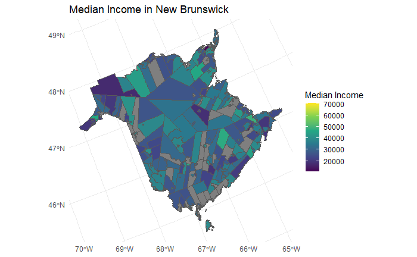

```r
?arc.data2sf

library(sf)
library(ggplot2)

# Convert ArcGIS data to an `sf` object
csd_sf <- arc.data2sf(csd_df)

# Filter for New Brunswick CSDs
csd_nb <- csd_sf %>%
  filter(grepl("New Brunswick", PRNAME))

# Show the income for CSDs in New Brunwswick::
ggplot(csd_nb) +
  geom_sf(aes(fill = income_median_t)) +
  scale_fill_viridis_c() +
  theme_minimal() +
  labs(title = "Median Income in New Brunswick",
       fill = "Median Income")
```

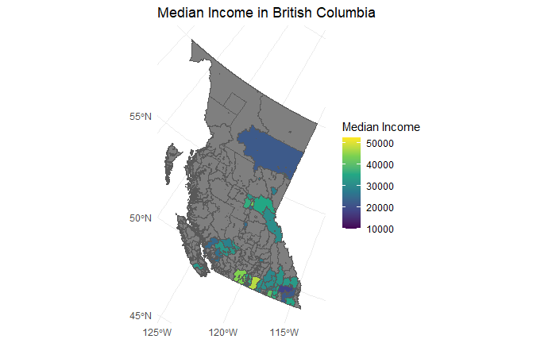

```r
# Filter for British Columbia
csd_bc <- csd_sf %>%
  filter(grepl("British Columbi", PRNAME))

# Show the income for CSDs in British Columbia:
ggplot(csd_bc) +
  geom_sf(aes(fill = income_median_t)) +
  scale_fill_viridis_c() +
  theme_minimal() +
  labs(title = "Median Income in British Columbia",
       fill = "Median Income")
```

With the `sf` package available for working with spatial data frames, we can perform additional operations like `left_join()` or `inner_join()` and retain the data frame’s spatial properties. For example, the earlier code block that created the `csd_income` data frame by performing a join with the `csd_df` data frame can be rewritten as follows:

```r
# Load Saskatchewan boundaries and income data:
sask_df <- arc.select(csd, fields = c("PRNAME", "CSDNAME", "CSDUID"), where_clause = "PRNAME like 'Sask%'")
income_df <- arc.open('data/census/census2016.gdb/income2016csd')  %>%
        arc.select(c("geo_code", "gnr", "pop2016_t", "popdens_t", "income_median_t"), where_clause = "gnr is not null and gnr < 25")
```

[output not shown]

```r
# Join income data to the saskatchewan boundaries using by using an intermediate sf data frame
csd_income_sf <- left_join(arc.data2sf(sask_df), income_df, by = c("CSDUID" = "geo_code"))

class(csd_income_sf)
```

```
[1] "sf"         "data.frame"
```

### Analyzing spatial data in R

There are many different spatial statistical analysis packages available for R. To get a thorough overview, refer to the Spatial CRAN Task View at https://cran.r-project.org/web/views/Spatial.html. Typically, the spatial analysis functions in each of package will work with specific structures of data, or specific data object types, such as `sf` data frames.

As an example, using the income data available for census subdivisions, we can calculate income inequality statistics using functions provided by the `ineq` package. In the code block below, we can generate a Lorenz curve and calculate the Gini coefficient for census subdivisions within Ontario to measure inequality of median income across the province.

**Note:** the `plot()` and `text()` command must be executed at the same time to work properly. When running these functions within the R-Markdown document in **RStudio**, either highlight all of the lines from the `plot()` command to the `text()` command and press **CTRL+Enter***, or run the entire block at once by pressing the button*

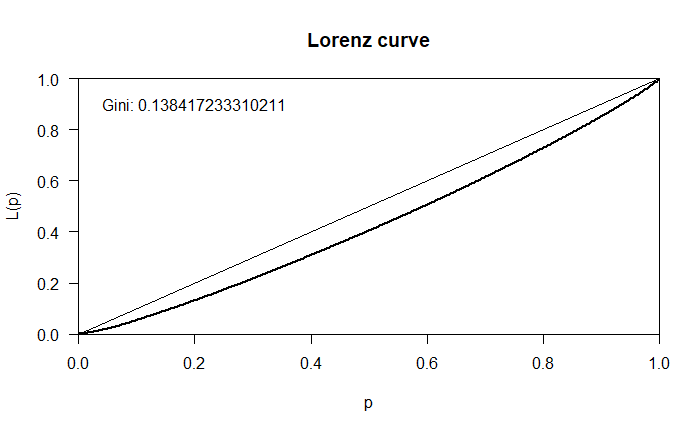

```r
# Load the ineq package:
library(ineq)

# Filter out N/A values for income, and limit to Ontario CSDs:
on_spdata <- csd_sf %>% filter(!is.na(income_median_t), grepl("Ontario", PRNAME))

# Calculate the lorenz curve:
?Lc
lc <- Lc(on_spdata$income_median_t)
plot(lc)

# Calculate the Gini coefficient, and add it to the plot:
?Gini
g <- Gini(on_spdata$income_median_t)
text(0.2,0.9,paste(c("Gini: ", as.character(g)), collapse=""))
```

**Note:** this analysis is for illustrative purposes only - income indicators aggregated at census subdivision levels will not reveal much of the inequality that occurs within the census subdivisions themselves

```r
library(lctools)

?spGini

# Extract centroids for polygon geometries
coords <- st_coordinates(st_centroid(on_spdata))
# You can now use these coordinates and the income data to calculate the Gini index
spG <- spGini(coords, 15, on_spdata$income_median_t)

# Display the Gini index result
spG
```

```
       Gini      gwGini      nsGini gwGini.frac nsGini.frac
0.138417233 0.004092195 0.134325038 0.029564203 0.970435797
```

```r
?mc.spGini

# Run a monte-carlo simulation to test significance:
spG.sim20 <- mc.spGini(Nsim=19, 15, on_spdata$income_median_t, coords[,1], coords[,2])
spG.sim20$pseudo.p
```

```
[1] 0.05
```

By running 19 (or more) simulations, it can be determined whether the observed results from `spGini()` are significant by obtaining pseudo p-value of 0.05 or lower (i.e., suggesting that the probability that the observed result is due to chance is 5% or less).

# Part D: Writing data from R to ArcGIS datasets

At this point, we have shown that ArcGIS datasets can be read easily into an R session, and demonstrated how you can manipulate spatial data frames, visualize the spatial data in map plots, and use the spatial data objects in spatial analyses. However, the **R-ArcGIS** bridge works in both directions, enabling you to further analyze, visualize, and collaborate by connecting the outputs of your R programs to the ArcGIS platform.

The simplest approach for this that the `arcgisbinding` package provides is to write your data to ArcGIS datasets using the `arc.write()` method. With this function, you can write spatial and tabular data frames, and raster objects to conventional ArcGIS dataset formats. The `arc.write()` method requires at least two arguments:

- `path`: the full or relative path to an ArcGIS dataset that will be created (e.g., *.shp, *.csv, *.dbf, *.gdb featureclass/table/raster, *.img, *.tif, etc.).
- `data`: the data frame to be written (ArcGIS or `sp` spatial data frame, or simple tabular data frame). This must be an ArcGIS spatial data frame, an `sp` data frame, an `sf` object, a simple tabular data frame, or a `RasterLayer` or `RasterBrick` object from the `raster` package.

If you are using the `arc.write()` method from to overwrite an output dataset, you can provide an additional `overwrite = TRUE` parameter to the arguments. This will delete any existing dataset at the output path, and replace it with the new one that you are writing.

**Note:** When writing output datasets, you will not see any error or confirmation prompt if a dataset at the specified path already exists when you provide the `overwrite = TRUE` option.

```r
?arc.write

arc.write('data/example.gdb/ontario_data', on_spdata, overwrite = TRUE)
```

## Choosing an output path for `arc.write()`:

When you specify the output path to use with `arc.write()`, ensure that you appropriately define a new path for a shapefile inside a regular folder, or to a new featureclass inside of an ArcGIS geodatabase. These paths may be relative, or absolute file locations (as with the `arc.open()` command), for example:

- `arc.write('example.gdb/ontario_data', on_spdata)` - creates a new feature class in an existing `example.gdb` file geodatabase
- `arc.write('data.sde/ontario_data', on_spdata)` - creates a new feature class in an existing enterprise geodatabse, identified by the `data.sde` connection file
- `arc.write('data/ontario_data.shp' on_spdata)` - creates a new shapefile in the `data` folder location

If you want to save tabular data, specify path to a new table name in a geodatabase, or an appropriate tabular file format in a folder. If you only want to save tabular data from a spatial data frame object (whether it is an `arcgisbinding`, `sp`, or `sf` data object), you can wrap the variable in the `data.frame()` function to discard the spatial information. For example:

- `arc.write('example.gdb/ontario_data_tbl', data.frame(on_spdata))` - creates a new table in an existing `example.gdb` file geodatabase
- `arc.write('data/ontario_data_tbl.dbf', data.frame(on_spdata)` - creates a new table in dBASE format in the `data` folder
- `arc.write('data/ontario_data_tbl.csv' data.frame(on_spdata))` - creates a new table in comma-separated variable text format in the `data` folder

**Note:** fieldnames in feature classes and tables will be truncated when written to shapefile or dBASE formats. When written to geodatabases, invalid characters in fieldnames will be converted to underscores, and fieldnames may otherwise be converted to upper or lowercase depending on the underlying database system.

If you are writing raster data objects, then you must similarly specify a path to a new dataset name in a geodatabase, or to an appropriate raster file format in a folder:

- `arc.write('example.gdb/raster_dataset', raster_data)` - creates a new raster dataset in an existing `example.gdb` file geodatabase
- `arc.write('data/raster_dataset.tif', raster_data)` - creates a GeoTiff file in the `data` folder

When an R script is run as a script tool in an ArcGIS Toolbox, overwriting output files is less of a concern when the paths are defined using output parameters. In this context, the ArcGIS geoprocessing environment will either prevent overwriting existing datasets, or cleanly remove them before executing the script tool (based on whether the geoprocessing option to allow tools to overwrite outputs is enabled). In this context, it should not be required to use the `overwrite` parameter.

## Working with spatial reference definitions:

In some cases, depending on your specific data source and/or the process through which your data are created, you may need to use different representations of spatial reference systems. The `arcgisbinding` package provides two convenience methods for converting between Well-known ID / Well-known Text and Proj.4 spatial reference systems definitions:

- `arc.fromWktToP4()` - converts a Well-known ID (a.k.a., SRID) or Well-known Text spatial reference to Proj.4 text
- `arc.fromP4ToWkt()` - converts a Proj.4 spatial reference text string to Well-known text format.

For example, to convert the standard web mercator projection from a its well-known ID to Proj.4 text, then back to a full WKT text string:

```r
wm_p4 <- arc.fromWktToP4(3857)
wm_p4
```

```
[1] "+proj=merc +a=6378137 +b=6378137 +lat_ts=0 +lon_0=0 +x_0=0 +y_0=0 +k=1 +units=m +nadgrids=@null +wktext +no_defs"
```

```r
wm_wkt <- arc.fromP4ToWkt(wm_p4)
wm_wkt
```

```
[1] "PROJCS[\"WGS_1984_Web_Mercator_Auxiliary_Sphere\",GEOGCS[\"GCS_WGS_1984\",DATUM[\"D_WGS_1984\",SPHEROID[\"WGS_1984\",6378137.0,298.257223563]],PRIMEM[\"Greenwich\",0.0],UNIT[\"Degree\",0.0174532925199433]],PROJECTION[\"Mercator_Auxiliary_Sphere\"],PARAMETER[\"False_Easting\",0.0],PARAMETER[\"Fa…
```

# Exercise 1

At this point, you are now able to read, manipulate, analyze, visualize, and write ArcGIS datasets in the R programming language using the `arcgisbinding` package installed by the **R-ArcGIS** bridge. To test your skills, try the following:

- Load the `data/toronto/neighbourhoods_crime.shp` shapefile into a new spatial data frame
- Load the `data/toronto/wb_civics_2011.csv` table into a new data frame, and join its columns to the neighbourhoods_crime data frame. *Hint: one of these stores its identifier as a character vector*
- Add a column with quantile ranks, group/summarize some of the data, create some box plots.
- Write the data with the columns added from the wb_civics_2011.csv data back to a new shapefile. *Hint: remember the result of a join using dplyr with an ArcGIS spatial data frame does not return shape data – copy columns back to the original data frame created by the arc.select() command, or convert the data to an `sp` spatial data frame, then use the join commands provided by the `spdplyr` package.*
- Add the new shapefile to your map in ArcGIS Pro or ArcMap, and style it by the quantile ranks you added.

# Future Considerations

The `arcgisbinding` package provided by the **R-ArcGIS** bridge is an effective tool to integrate ArcGIS datasets efficiently into your R programs. It also allows you to generate new ArcGIS datasets as outputs from your R programs to make results from your analyses easily viewed and processed in ArcGIS applications. This is a significant advantage for developing R programs that need to work with spatial datasets that are easily managed by ArcGIS applications.

Integration of your R scripts with the ArcGIS platform is even more effective if you implement them as script tools in an ArcGIS toolbox. Doing so makes input/output of datasets and numerical/text parameter values seamless, and enables immediate visualization of feature classes and tables output by your tools. Your R script tools can be further integrated into larger processes, for example by incorporating them into an ArcGIS Model Builder workspace, or importing them to Python scripts using ArcPy commands to create more advanced geoprocessing workflows.

It is highly recommended that you continue the tutorial series by completing the *Building R Script Tools* tutorial. This will teach you how to create toolboxes that integrate your R code with ArcGIS Pro or ArcGIS Desktop.

[figure not shown]

# https://hed.esri.ca

© 2024 Esri Canada. All rights reserved. Trademarks provided under license from Environmental Systems Research Institute Inc. Other product and company names mentioned herein may be trademarks or registered trademarks of their respective owners. Errors and omissions excepted. This work is licensed under a Creative Commons Attribution-NonCommercial-ShareAlike 4.0 International License.